# Final Project

# Final Project

UVA SEAS Salary and Gender

Megan Lin, James Powell, Eva Mustafic

5/5/2021

## Question of Interest

For this project, we were interested to see if there was a Glass Ceiling at UVA– specifically if there was a significant difference between male and female salaries at UVA. In order to explore that, we explored the questions:

1. Is gender a top determining factor within the top N% of faculty at UVA?

2. Can we predict an employee’s gender based on their salary? What about if we add in tenure and/or department?

We decided to use a Decision Tree to explore which of these variables would be most important in determining gender.

For our analysis we were interested to see if there was a difference between male and female when it comes to salaries at UVA. In order to explore that, we started of with a question:

1. Is gender a top determining factor within the top N% of faculty at UVA?

2. Can we predict the gender based on salary (as well as other variables)?

For that purposes we decided to use Decision Tree model and as we will explain later, had more success in explaining what role does gender play at UVA faculty positions.

## Data

The Cavalier Daily’s dataset was used to merge the salary into the dataset based on name. However, some names were not matched up because some faculty members use nicknames or had a change in last name likely due to getting married recently. Faculty members who were not found in the Cavalier Daily were manually double checked and their salaries were added if the department, role, and first name or last name matched up.

Multiple online name and gender dictionaries were used in conjunction with a Python program to determine the gender of the faculty member based on their first name since this information was not readily available. If any of the dictionaries labeled the name as indeterminately female/male (aka a gender-neutral name like Alex), the faculty member was given a ? for gender even if another gender dictionary gave it a determinate female or male labeling. If the gender was not found in any of the datasets, it was given a NA for gender.

In our evaluation, we will only be looking at faculty members who have a determinate female or male name.

### Reading in the Data

The data has previously been merged and cleaned using Python, but we are going to make sure all of the rows with incomplete data are filtered out. Specifically, we will be filtering out employees with a gender the Python program was unable to find in any existing gender-name dictionaries or was deemed to be a gender-neutral name like Alex.

| Department | Position | Tenure | Full.Name | ID | Dpt | First.Name | Last.Name | Gender | Salary |
| --- | --- | --- | --- | --- | --- | --- | --- | --- | --- |
| BME | Lecturer | AGF | Chen, David | dc9rk | SOM | David | Chen | M | $120,967.00 |
| BME | Assistant Professor | AGF | Barker, Shannon D | sb3xk | BME | Shannon | Barker | F | $91,000.00 |
| BME | Assistant Professor | On Track | Civelek, Mete | mc2wq | SOM | Mete | Civelek | M | $110,800.00 |
| BME | Assistant Professor | On Track | Griffin, Don | dg2gf | BME | Don | Griffin | M | $128,000.00 |
| BME | Assistant Professor | On Track | Highley, Christopher H | ch2qm | BME | Christopher | Highley | M | $127,900.00 |
| BME | Assistant Professor | On Track | Zunder, Eli | ez8v | BME | Eli | Zunder | M | $129,000.00 |

### Data Walkthrough

#### Gender Distribution

To determine the split, we had to determine the ratio of female to total, and based on that, we can deduce the percent of male entries, and the percentage of both. To do this we created the function ad_split, which prints the ratio of female to total entries and ran it on the clean salary dataset. The split between female to male is 22 percent to 78 percent within the School of Engineering, respectively.

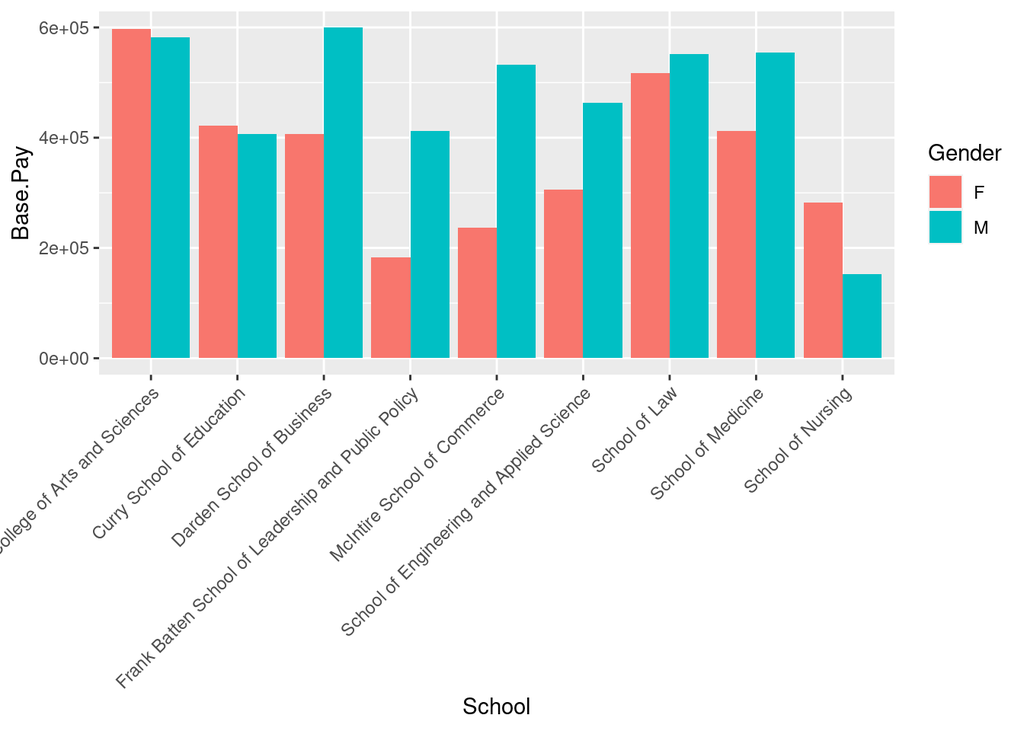

[figure not shown]

Graph of Average Salary in SEAS by Factor

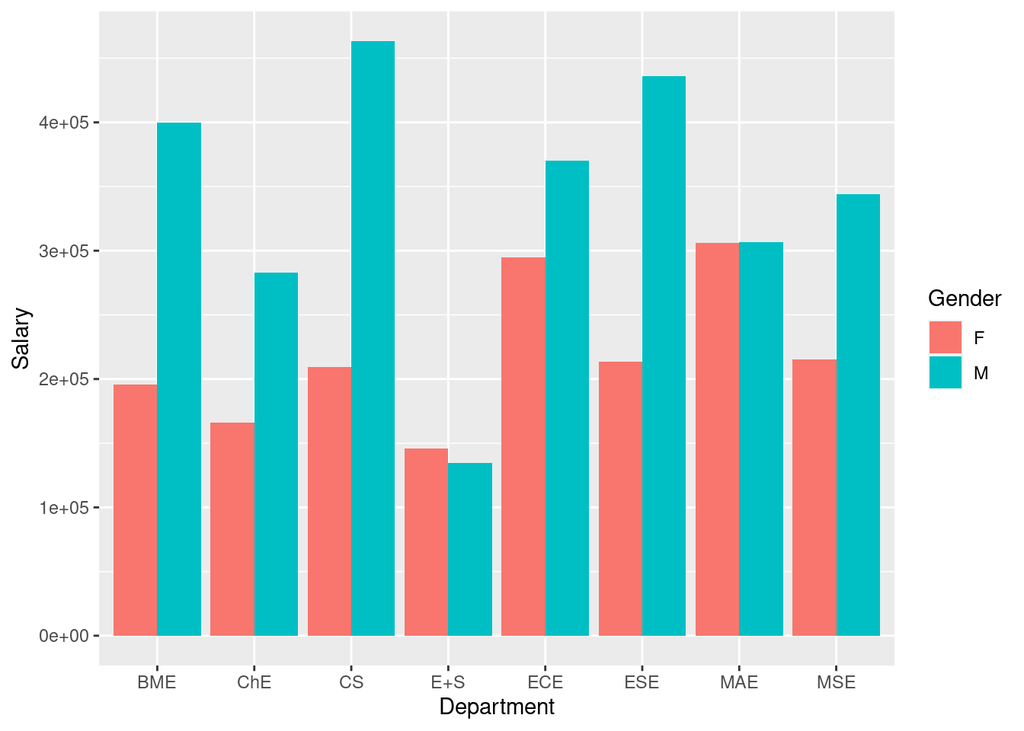

Between all UVA schools

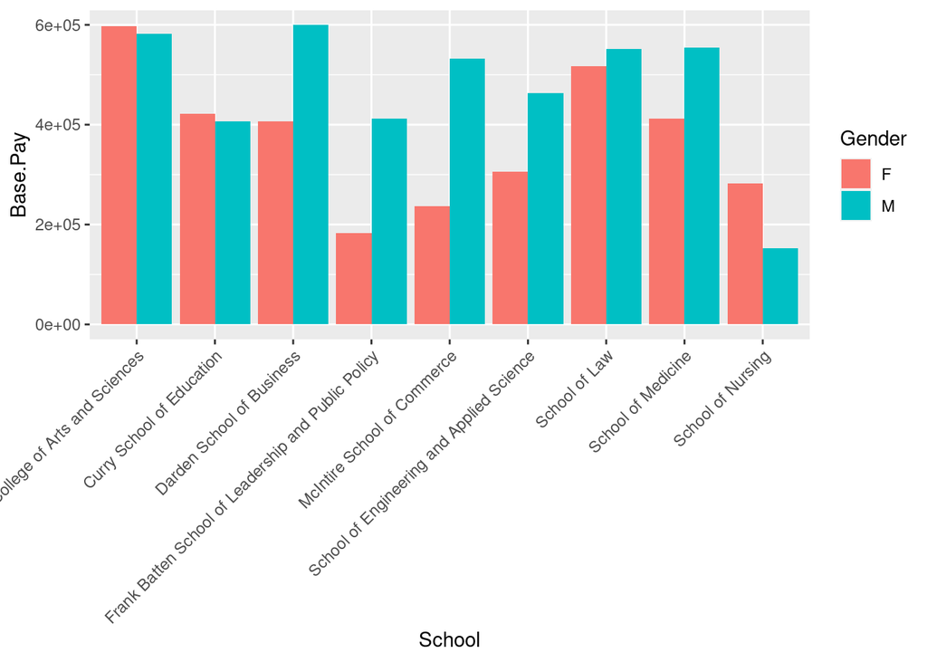

Across departments

### Cleaning the Data

To filter out the vars, we create a list of the vars names and saved the dataset over itself without the columns in the vars variable.

```
## Department   Position     Tenure     Gender     Salary
##  "numeric"  "numeric"  "numeric"  "numeric"  "numeric"
```

## Approach #1: KNN

### Generate Training and Testing Sets

### Data Sets

#### Training Data

|  | Department | Position | Tenure | Gender | Salary |
| --- | --- | --- | --- | --- | --- |
| 15 | 1 | 5 | 3 | 1 | 195500 |
| 112 | 5 | 1 | 2 | 1 | 135400 |
| 186 | 8 | 5 | 3 | 2 | 185200 |
| 161 | 6 | 5 | 3 | 2 | 221400 |
| 60 | 3 | 1 | 2 | 1 | 152800 |
| 111 | 5 | 1 | 1 | 2 | 86700 |

#### Testing Data

|  | Department | Position | Tenure | Gender | Salary |
| --- | --- | --- | --- | --- | --- |
| 1 | 1 | 4 | 1 | 2 | 120967 |
| 2 | 1 | 1 | 1 | 1 | 91000 |
| 4 | 1 | 1 | 2 | 2 | 128000 |
| 10 | 1 | 2 | 3 | 2 | 150700 |
| 19 | 1 | 5 | 3 | 2 | 166400 |
| 24 | 1 | 5 | 3 | 2 | 157311 |

## Approach #2: Decision Trees

### Cleaning the Data

To filter out the vars, we create a list of the vars names and saved the dataset over itself without the columns in the vars variable.

Gender: Male is 1, Female is 0

### Splitting

We will start off our decision tree by splitting the data into a training and a testing set

### Building the Model

We build our model using the default setting and by using the rpart function. Gender is used as the “formula” aka our response variable. We utilize our previously split training dataset and set a cp of 0.01 as it is our default.

### Decision Tree

#### Visually

First, we can take a look to see the order of importance of the employee’s other factors that we can use to guess gender with.

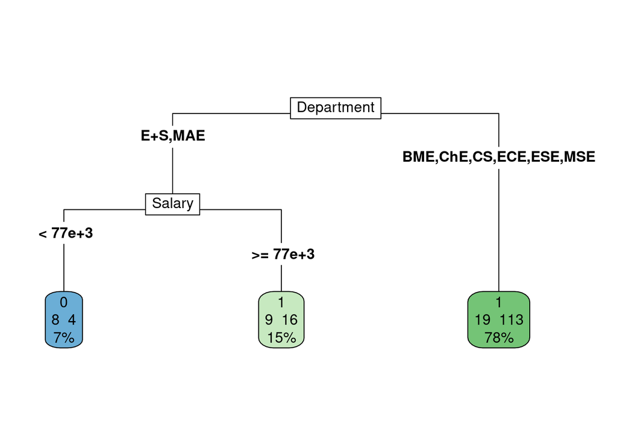

Most important is the department that the employee is.

If they are in E+S (APMA) or MAE, then salary is the secondmost important. If their salary is below 77k, they are assigned by the decision tree to be a female If they are over 77k, they are male

If they are in any other department, they are determined to be male as amongst these departments, there are 113 males to 19 females.

#### Variable Importance

|  | x |
| --- | --- |
| Department | 6.3894759 |
| Salary | 2.9246765 |
| Position | 1.2006388 |
| Tenure | 0.3812613 |

In order of decreasing importance, department, salary, position, then tenure are the most important factors within the School of Engineering that can be used to accurately determine the faculty member’s gender.

Ideally, the order would have been department, position, tenure, then salary. Department would be at the top of the list because this is for the most part, employee-chosen. Position would be next because this would also be driven by drive by the employee member and their background coming into UVA. Third is tenure which is similar to position, but has less to do with the employee’s resume coming into UVA and moreso how UVA treats the employee throughout their time at UVA. If this factor was ranked higher, it would indicate that there is likely bias in UVA’s own process at choosing professors for tenure. However, there is still a level of employee drive and initiative to even apply for being on track for tenure vs. staying as an AGF. Last is salary because salary is more reactive to the employee’s current responsibilities and role at UVA. Tenure is similarly important, but can take 5-20 years for the university to make a binary choice versus the university reevaluating the professor’s salary each year.

Next, we use the predict function to predict the target variable.

Salary

2.924676

Position

1.200639

In order of decreasing importance, department, salary, then position are the most important factors within the School of Engineering that can be used to accurately determine the faculty member’s gender.

Ideally, the order would have been department, position, tenure, then salary. Department would be at the top of the list because this is for the most part, employee-chosen. Position would be next because this would also be driven by drive by the employee member and their background coming into UVA. Third is tenure which is similar to position, but has less to do with the employee’s resume coming into UVA and moreso how UVA treats the employee throughout their time at UVA. If this factor was ranked higher, it would indicate that there is likely bias in UVA’s own process at choosing professors for tenure. However, there is still a level of employee drive and initiative to even apply for being on track for tenure vs. staying as an AGF. Last is salary because salary is more reactive to the employee’s current responsibilities and role at UVA. Tenure is similarly important, but can take 5-20 years for the university to make a binary choice versus the university reevaluating the professor’s salary each year.

### Prediction

Next, we use the predict function to predict the target variable.

## Things to Keep in Mind

Because of how we used gender dictionaries to assign genders to the employees rather than obtaining that data from the employee, there were difficulties determining genders for gender-neutral names or names that did not appear in these dictionaries. While gender-neutral named groups are misrepresented, it is likely that these are well-spread between genders, departments, and tenure.

The more concerning group that is underrepresented are the employees who have names that do not appear in the gender dictionaries we used. These are more likely to be foreign employees since the gender dictionaries we used were written in English. Thus, it is likely that departments that have larger groups of foreign employees like the computer science department are misrepresented in our analysis.